# MI Network and Hypergraph Analysis with miEdgeR

## About this vignette

This walkthrough demonstrates how to build mutual-information (MI) networks and hypergraphs from single-cell RNA-seq data using miEdgeR. We extract cluster-specific gene expression, compute pairwise MI, refine networks through percolation and community detection, and finally assemble and visualize a hypergraph of gene modules.

Prerequisites:

R (≥ 4.2.0)

Packages: miEdgeR, Seurat, igraph, hypergraph, dplyr, ggplot2, ggraph, flextable

## Introduction

This vignette walks through the key steps of MI network construction and higher-order hypergraph analysis. Starting with a Seurat object we show how to filter for highly variable genes, compute and threshold MI, remove noise with percolation, detect communities, and finally represent those communities as hyperedges.

## Load Libraries and Data

We load all necessary packages and read in the preprocessed Seurat object. Ensure your object contains a clustering column (RNA_snn_res.0.1 in seurat demo pbmc3K data) corresponding to cluster IDs.

```r
library(Seurat)
library(miEdgeR)
library(igraph)
library(dplyr)
library(ggplot2)
library(ggraph)
library(flextable)

seurat_obj <- readRDS('pbmc3k.rds')
```

## Data exploration

Exploring the preprocessed pbmc3k data. For this tutorial we will focus on CD14+ Mono cluster “1”

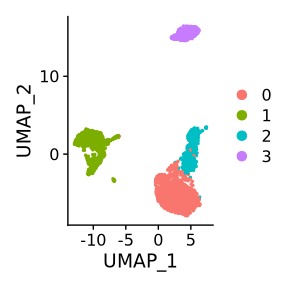

```r
DimPlot(seurat_obj, reduction = 'umap')
```

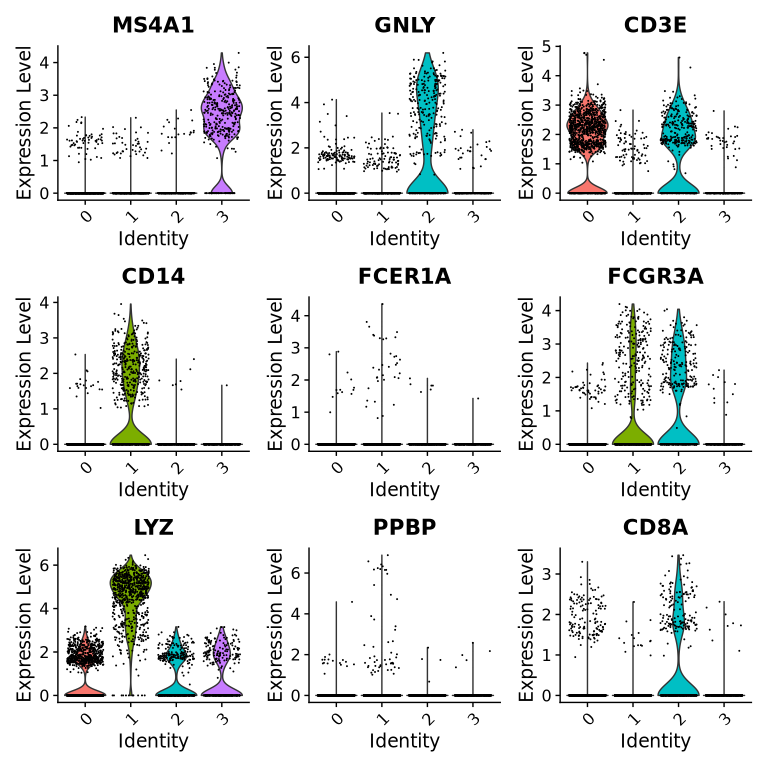

```r
features = c("MS4A1", "GNLY", "CD3E", "CD14",
             "FCER1A", "FCGR3A", "LYZ", "PPBP", "CD8A")
VlnPlot(seurat_obj, features = features)
```

## Building a Mutual-Information Network

Here we call `compute_mi_network()`, which under the hood:

1. Extracts expression for cluster “1” (up to 1,500 cells; genes > 5% of cells).
2. Filters to the top 3,000 most variable genes (after removing housekeeping genes).
3. Discretizes expression (adaptive binning) and computes pairwise MI in parallel.
4. Constructs an undirected igraph object by thresholding at the 95th percentile of MI values.

You can adjust `percentile` (e.g. 0.90 for more liberal edges) or supply `fixed_threshold` for absolute MI cutoffs.

Note: computing mi-network can be computationally demanding. We strongly advice to limit the number of cells and genes to the most variable ones

```r
result <- compute_mi_network(
  seurat_obj,
  cluster_id = "1",
  cluster_field = "RNA_snn_res.0.1",
  assay_name = "RNA",
  counts_layer = "counts",
  data_layer = "data",
  min_expr_pct = 0.05,
  top_n_genes = 3000,
  n_cores = 65
)
```

```
## Using adaptive nbins = 9
```

```r
mi_matrix <- result$mi_matrix
graph_percentile <- build_mi_graph(mi_matrix,
                                   threshold_method = "percentile",
                                   percentile = 0.95)
cat("Vertices:", vcount(graph_percentile), "\n")
```

```
## Vertices: 2911
```

```r
cat("Edges:", ecount(graph_percentile), "\n")
```

```
## Edges: 211804
```

```r
cat("Density:", graph.density(graph_percentile), "\n")
```

```
## Density: 0.05000679
```

The resulting MI matrix was filtered using the 95th percentile threshold with `build_mi_graph()`, producing a graph with 2911 genes (nodes), 211,804 edges, and a density of ~0.05. This indicates substantial gene-gene co-dependence within the cluster.

## Consensus Edges via Percolation

Real-world networks can be noisy. We apply a simple “percolation” strategy:

- **Pre-filter**: Keep only the top 5% of edges by weight.
- **Resample** 100 times, each time retaining 60% of edges at random.
- **Consensus**: Edges appearing in ≥ 50% of iterations are considered stable.

This yields a consensus graph that filters out spurious edges.

```r
g_consensus <- percolate_graph(graph_percentile, n_iterations = 100,
                               edge_fraction = 0.6, freq_threshold = 0.5,
                               percentile = 0.95)
set.seed(123)
lc_comm <- cluster_label_prop(g_consensus, weights = E(g_consensus)$weight)
lc_groups <- split(V(g_consensus)$name, membership(lc_comm))
lc_groups <- Filter(function(x) length(x) >= 10, lc_groups)

# Neighborhood overlap
adj_matrix <- as_adjacency_matrix(g_consensus, attr = "weight", sparse = FALSE)
overlap_threshold <- 0.1
for (node in V(g_consensus)$name) {
  idx <- which(V(g_consensus)$name == node)
  neighbors <- V(g_consensus)$name[adj_matrix[idx, ] > 0]
  if (length(neighbors) == 0) next
  for (i in seq_along(lc_groups)) {
    comm_genes <- lc_groups[[i]]
    ov <- length(intersect(neighbors, comm_genes)) / length(neighbors)
    if (ov >= overlap_threshold && !(node %in% comm_genes)) {
      lc_groups[[i]] <- c(comm_genes, node)
    }
  }
}

large_communities <- lc_groups
cat("Communities (size >= 10):", length(large_communities), "\n")
```

```
## Communities (size >= 10): 2
```

```r
cat("Sizes:", sapply(large_communities, length), "\n")
```

```
## Sizes: 571 93
```

Community detection was performed with label propagation (`cluster_label_prop()`), yielding two robust gene communities (sizes: 571 and 93). A neighborhood overlap step further enriched communities by including strongly connected neighboring genes.

## Clustering coefficient

Compute additional network metrics for the consensus graph.

```r
clustering_coeff <- transitivity(g_consensus, type = "global")
cat("Global clustering coefficient:", clustering_coeff, "\n")
```

```
## Global clustering coefficient: 0.3873887
```

```r
# Centrality measures (degree, betweenness, closeness)
degree_centrality <- degree(g_consensus)
betweenness_centrality <- betweenness(g_consensus)
closeness_centrality <- closeness(g_consensus)

# Top 5 genes by each centrality measure
top_degree <- names(sort(degree_centrality, decreasing = TRUE))[1:10]
top_betweenness <- names(sort(betweenness_centrality, decreasing = TRUE))[1:10]
top_closeness <- names(sort(closeness_centrality, decreasing = TRUE))[1:10]

# Create a summary table
centrality_table <- data.frame(
  Metric = c("Degree", "Betweenness", "Closeness"),
  Top_Genes = c(
    paste(top_degree, collapse = ", "),
    paste(top_betweenness, collapse = ", "),
    paste(top_closeness, collapse = ", ")
  ),
  stringsAsFactors = FALSE
)
ft_centrality <- flextable::flextable(centrality_table) %>%
  flextable::autofit() %>%
  flextable::set_header_labels(Metric = "Centrality Metric", Top_Genes = "Top 5 Genes") %>%
  flextable::bg(part = "header", bg = "gray") %>%
  flextable::theme_vanilla()
ft_centrality
```

| Centrality Metric | Top 5 Genes |
| --- | --- |
| Degree | ATP5D, PSMA7, NEDD8, COPE, C19orf43, C11orf31, LSP1, UQCR11.1, ATP6V1F, EIF3G |
| Betweenness | S100A8, NEDD8, ATP5D, LDHA, LYZ, BRK1, COPE, HIGD2A, LAMTOR1, BST2 |
| Closeness | ATP5D, NEDD8, PSMA7, C19orf43, LSP1, COPE, TALDO1, UQCR11.1, ITGB2, AP2S1 |

We assessed the topology of the consensus MI network using global clustering coefficient (`transitivity()`), which was moderately high, indicating local gene co-regulation. Centrality analysis identified key genes based on degree, betweenness, and closeness, highlighting potential regulatory hubs such as **ATP5D**, **NEDD8**, and **COPE**. These central genes may play critical roles in cluster-specific transcriptional programs.

## Network Visualization

Visualize a subset of the MI network. Nodes are colored by community, and top hub genes per community are labeled. The plot highlights distinct gene modules with highly connected core genes such as ATP5D, PSMA7, and LYZ.

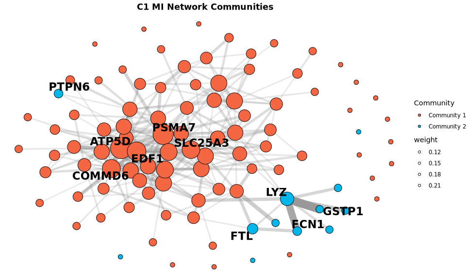

```r
plot_mi_network(g_consensus, large_communities, title = "C1 MI Network Communities")
```

## Hypergraph Visualization

To visualize overlapping gene communities, we constructed a hypergraph where genes are connected to their assigned communities. Overlapping genes (shared across communities) are highlighted in red, community nodes in green, and unique genes in blue. This representation captures complex gene sharing across modules, emphasizing central roles for genes like **LYZ**, **GSTP1**, and various MHC class genes.

```
## Overlapping genes: 92
## Shared genes: CD52, CD99, CEBPB, CFL1, CTSC, FTL, GRN, HLA-DRA, IFITM2, IFITM3, LY6E, MS4A6A, NAP1L1, PTPN6, S100A4, S100A6, S100A8, S100A9, SOD1, STXBP2, TIMP1, TUBA1B, TYROBP, UBC, VIM, YBX1, ARPC1B, VPS28, CST3, HLA-DMB, HLA-DQA2, HLA-DQB1, PSAP, ODF3B, ABI3, PSMB6, GNB2L1, NACA, ADA, IFITM1, …
```

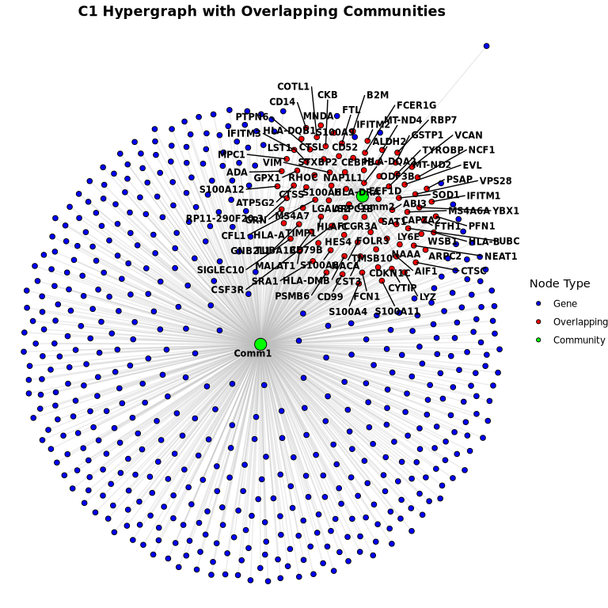

```r
plot_hypergraph(large_communities, comm_indices = c(1, 2),
                title = "C1 Hypergraph with Overlapping Communities")
```

## Community Sizes

Visualize community sizes.

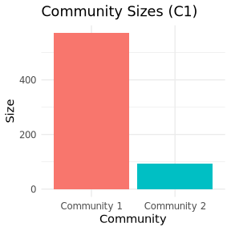

```r
comm_sizes_df <- data.frame(
  Community = paste("Community", seq_along(sapply(large_communities, length))),
  Size = sapply(large_communities, length)
)
p_comm_sizes <- ggplot(comm_sizes_df, aes(x = Community, y = Size, fill = Community)) +
  geom_bar(stat = "identity") +
  labs(title = "Community Sizes (C1)", x = "Community", y = "Size") +
  theme_minimal() +
  theme(legend.position = "none")
print(p_comm_sizes)
```

## Hub Genes Table from Full Graph

Generate a table of top hub genes (by degree) for each community using the full graph.

```r
summarize_hub_genes(graph_percentile, large_communities, cluster_name = "C1")
```

| Cluster | Community | Top Hub Genes |
| --- | --- | --- |
| C1 | Community 1 | S100A8, HLA-DPA1, ATP5D, C19orf43, HNRNPA2B1, TALDO1, PSMA7, NPM1, EIF3K, NDUFA11 |
|  | Community 2 | S100A8, S100A9, IFITM2, LYZ, GPX1, YBX1, LST1, IFITM3, LGALS2, CEBPB |

We identified top hub genes within each community by ranking nodes based on degree centrality. Using `summarize_hub_genes()`, we extracted key genes likely involved in core regulatory processes. For example, **S100A8**, **ATP5D**, and **HLA-DPA1** emerged as central in Community 1, while **S100A9**, **LYZ**, and **IFITM2** were prominent in Community 2. These hubs may serve as key functional markers or regulatory nodes in the cluster.

## Hub Genes

Identify top hub genes for communities from percolated graph.

```r
summarize_hub_genes(g_consensus, large_communities, cluster_name = "C1")
```

| Cluster | Community | Top Hub Genes |
| --- | --- | --- |
| C1 | Community 1 | ATP5D, PSMA7, NEDD8, COPE, C19orf43, C11orf31, LSP1, UQCR11.1, ATP6V1F, EIF3G |
|  | Community 2 | S100A8, LYZ, S100A9, IFITM2, FCGR3A, LST1, FCER1G, GPX1, AIF1, LGALS2 |